# Production solaire et consommation

Author

Hugo

## Production des panneaux solaires EcoFlow

**Production des panneaux solaires depuis mai 2025.**

Le jour où les panneaux ont produit le plus d’énergie fut le 17 juillet 2025 pour un total de 5487 Wh.

À l’inverse, le 07 décembre 2025, les panneaux ont produit la plus faible quantité d’énergie (89 Wh), hors jours à 0 Wh (par exemple jours de neige).

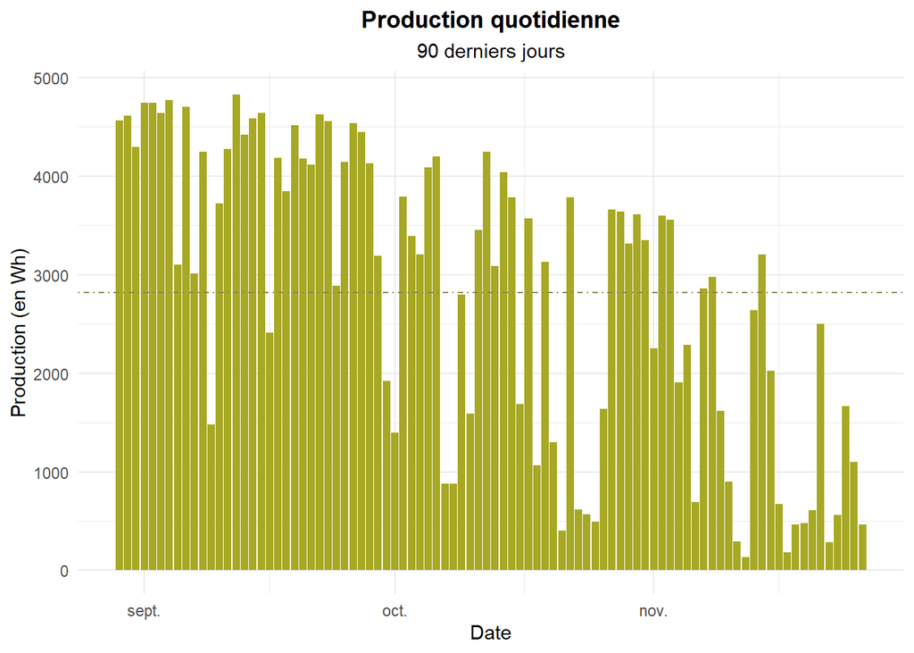

En moyenne, sur les 90 derniers jours, la production quotidienne s’élève à 2818 Wh.

Le graphique suivant compare la production entre le dernier jour (26 novembre 2026; 465 Wh) et le jour de production max. 17 juillet 2025

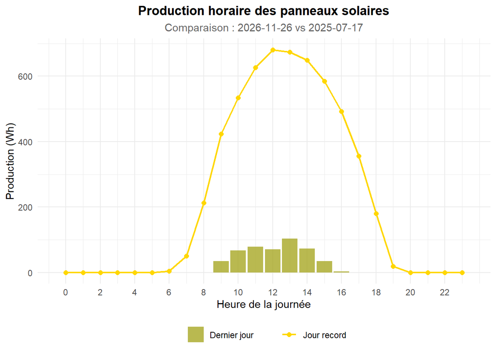

### Graphiques pour la production hebdomadaire

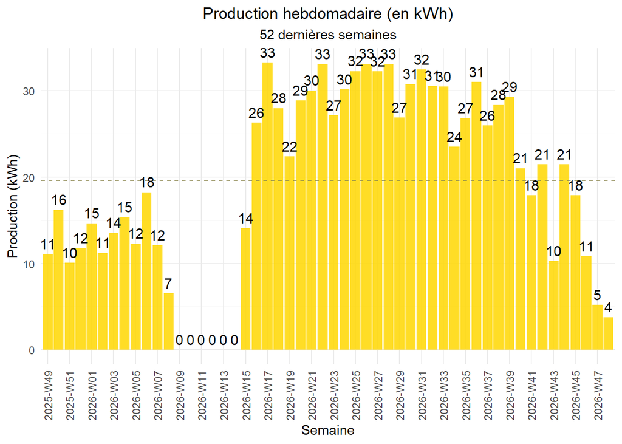

La production hebdomadaire moyenne (des 52 dernières semaines sans la semaine en cours) est de 19.589 kWh.

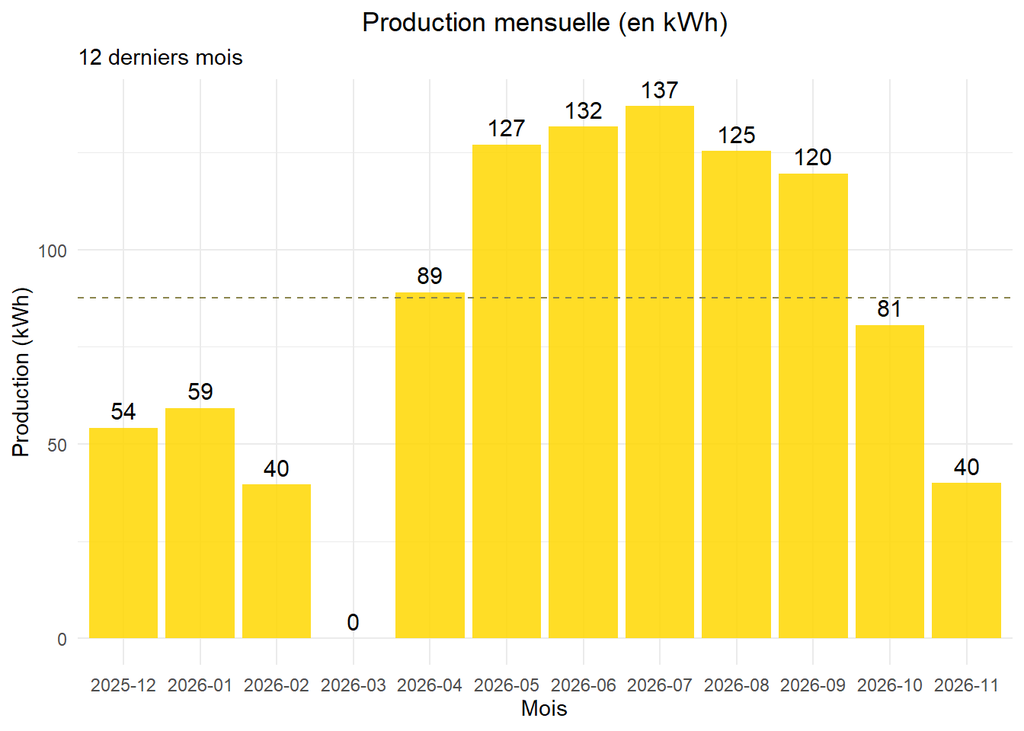

Alors que la production mensuelle moyenne (12 derniers mois; sans le mois en cours) est de 87.5 kWh.

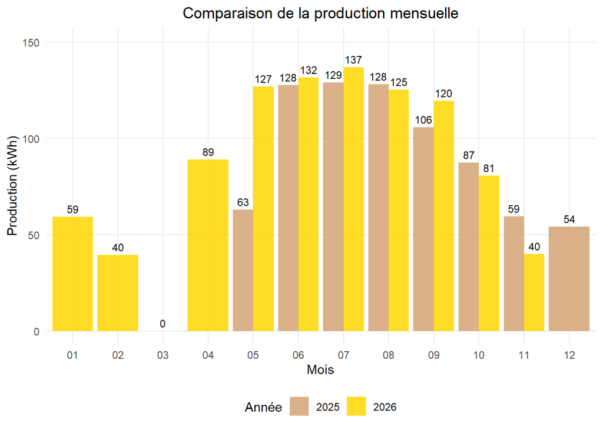

### Classements des 10 jours les plus et les moins productifs

**Les 10 meilleurs jours**

Les 10 meilleurs jours

| Date | Production (Wh) |
| --- | --- |
| 17.07.2025 | 5 487 |
| 10.07.2025 | 5 411 |
| 09.07.2025 | 5 406 |
| 24.05.2025 | 5 382 |
| 12.07.2025 | 5 365 |
| 08.06.2025 | 5 354 |
| 11.06.2026 | 5 314 |
| 27.07.2026 | 5 297 |
| 18.05.2025 | 5 292 |
| 04.07.2026 | 5 287 |

**Les 10 moins bons jours***

*Sans les jours à production nulle

Les 10 moins bons jours

| Date | Production (Wh) |
| --- | --- |
| 07.12.2025 | 89 |
| 12.11.2026 | 133 |
| 30.12.2025 | 135 |
| 24.12.2025 | 139 |
| 25.11.2025 | 148 |
| 17.11.2026 | 184 |
| 27.10.2025 | 188 |
| 09.01.2026 | 215 |
| 02.11.2025 | 239 |
| 20.10.2025 | 244 |

**Les 5 meilleurs jours par année**

Les 5 meilleurs jours par année

| Rang | 2025 Date | 2025 Prod. (Wh) | 2026 Date | 2026 Prod. (Wh) |
| --- | --- | --- | --- | --- |
| 1 | 17.07.2025 | 5 487 | 11.06.2026 | 5 314 |
| 2 | 10.07.2025 | 5 411 | 27.07.2026 | 5 297 |
| 3 | 09.07.2025 | 5 406 | 04.07.2026 | 5 287 |
| 4 | 24.05.2025 | 5 382 | 13.06.2026 | 5 274 |
| 5 | 12.07.2025 | 5 365 | 02.07.2026 | 5 220 |

**Les 5 moins bon jours par année**

Les 5 moins bons jours par année

| Rang | 2025 Date | 2025 Prod. (Wh) | 2026 Date | 2026 Prod. (Wh) |
| --- | --- | --- | --- | --- |
| 1 | 07.12.2025 | 89 | 12.11.2026 | 133 |
| 2 | 30.12.2025 | 135 | 17.11.2026 | 184 |
| 3 | 24.12.2025 | 139 | 09.01.2026 | 215 |
| 4 | 25.11.2025 | 148 | 16.02.2026 | 249 |
| 5 | 27.10.2025 | 188 | 12.02.2026 | 256 |

Nombre de jours avec production supérieure à 5 kWh: 55

Nombre de jours avec production inférieure à 1 kWh: 48

Production entre le 15 mai 2025 et le 14 mai 2026: 993.79 kWh.

Production depuis le 15 mai 2026: 709.373 kWh.

## Consommation électrique

La consommation est mesurée par le *smart meter* Shelly Pro 3 EM. Ce dispositif ne mesure que la consommation dans l’appartement. Sont donc exclus la consommation dans la cave/buanderie (lave-linge et sèche-linge) ainsi que le garage (borne de recharge).

### Consommation électrique quotidienne et horaire

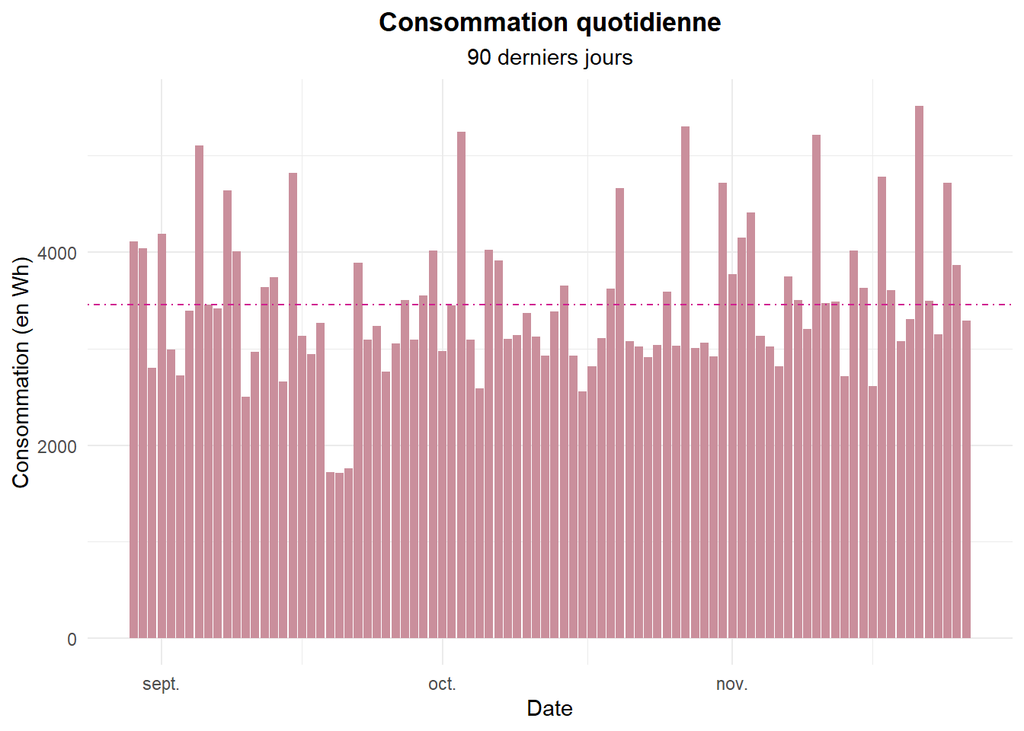

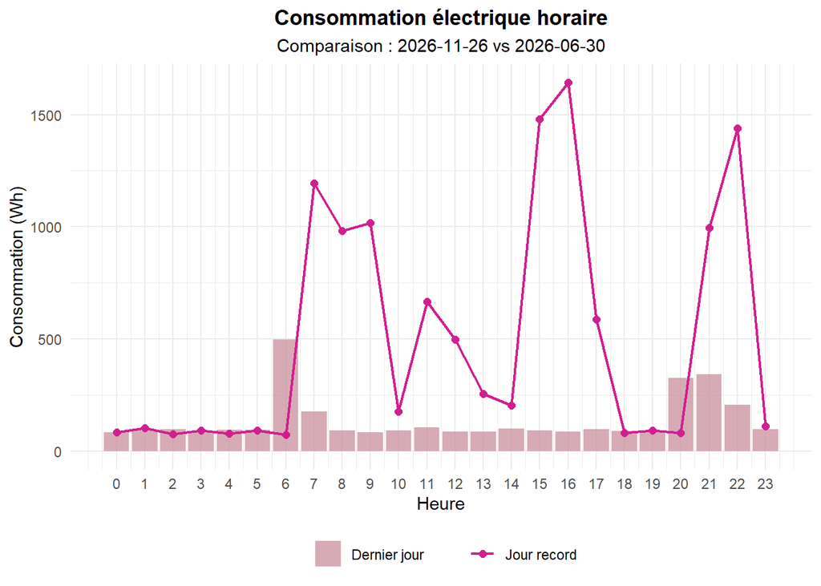

La consommation quotidienne moyenne est de 3453 Wh.

### Consommation électrique hebdomadaire et mensuelle

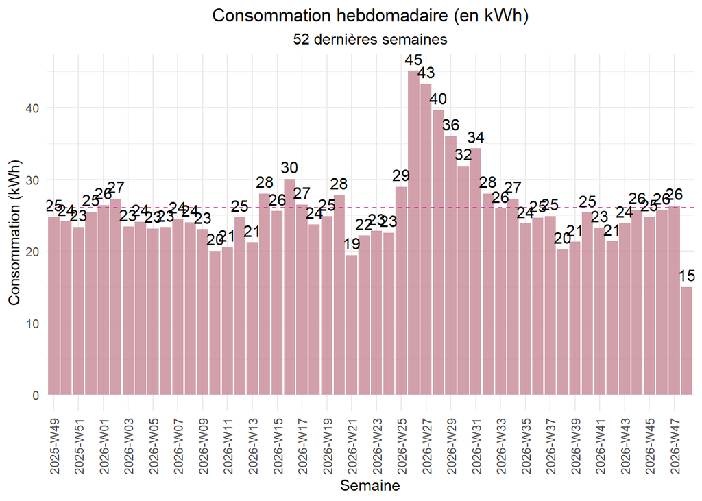

La consommation hebdomadaire moyenne (sans la semaine en cours) est de 26.063 kWh.

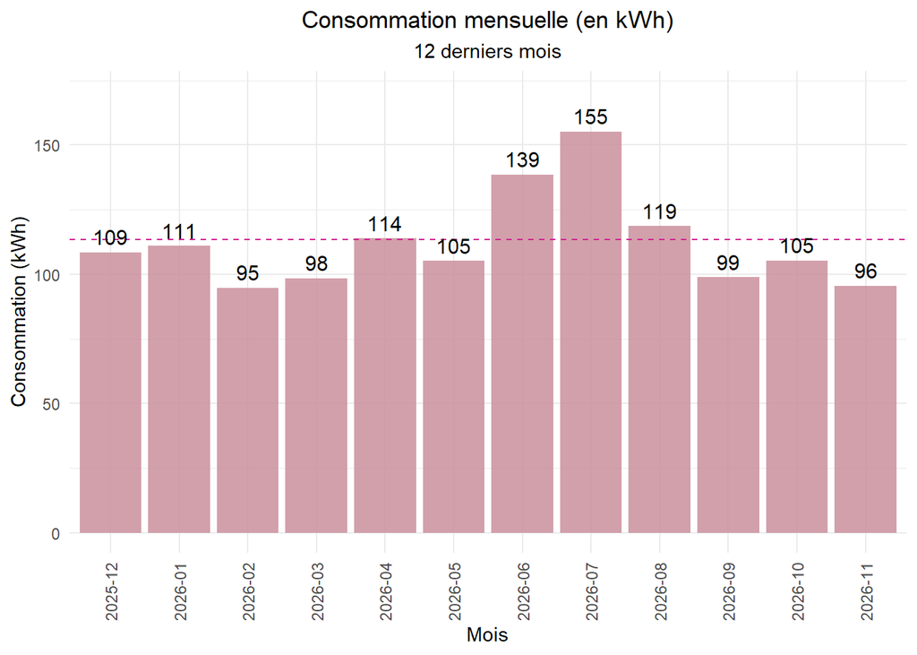

Alors que la consommation mensuelle moyenne (sans le mois en cours) est de 113.508 kWh.

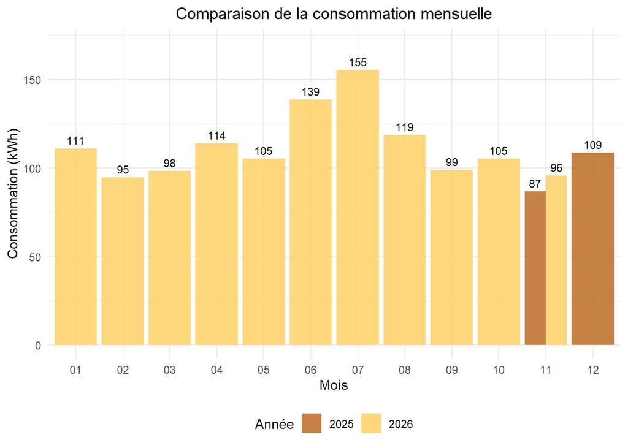

## Production et consommation

Graphique combiné production et consommation électrique du dernier jour complet.

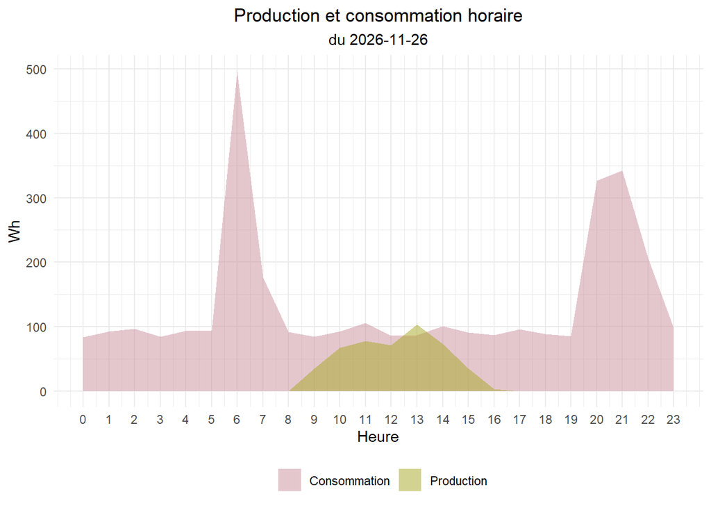

## Autoconsommation

### Autoconsommation et taux de couverture mensuels

Prise en compte de la batterie: on s’intéresse au moment où l’energie est envoyée à la maison

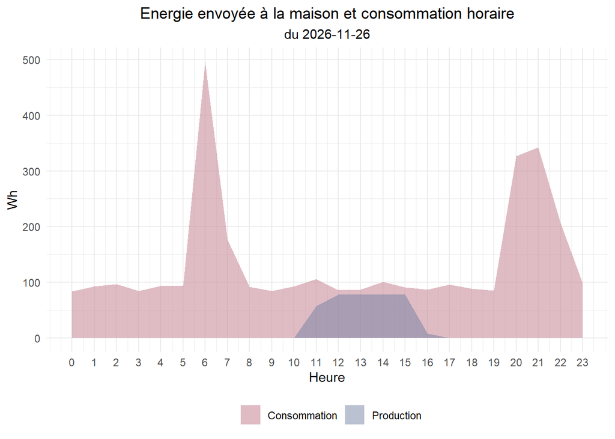

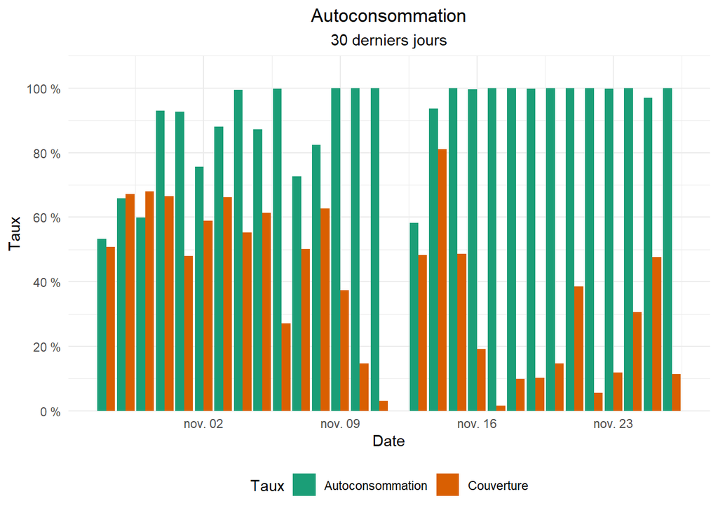

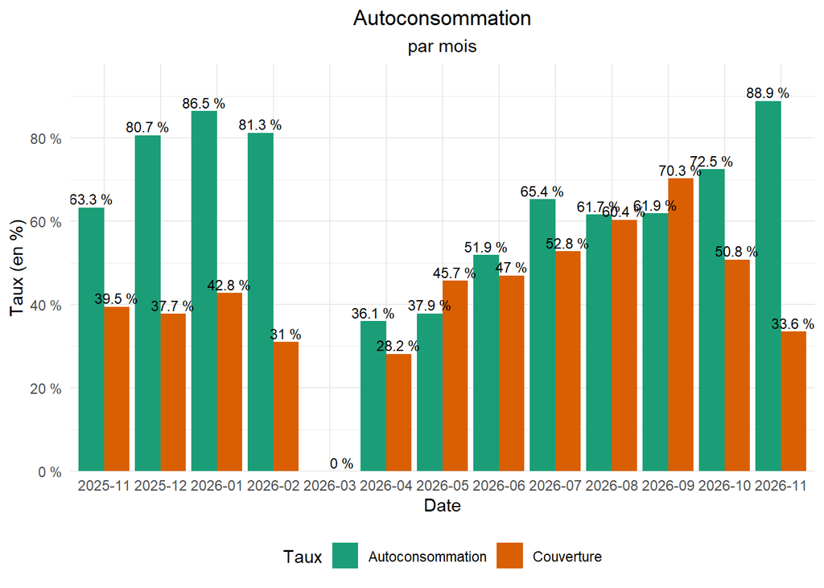

**Taux d’autoconsommation et de couverture des 10 derniers jours**

Taux d'autoconsommation et de couverture

10 derniers jours

| Date | Autoconsommation | Taux de couverture |
| --- | --- | --- |
| 26.11.2026 | 100.0 % | 11.5 % |
| 25.11.2026 | 97.0 % | 47.7 % |
| 24.11.2026 | 100.0 % | 30.5 % |
| 23.11.2026 | 99.8 % | 11.9 % |
| 22.11.2026 | 100.0 % | 5.7 % |
| 21.11.2026 | 100.0 % | 38.6 % |
| 20.11.2026 | 100.0 % | 14.8 % |
| 19.11.2026 | 99.8 % | 10.2 % |
| 18.11.2026 | 100.0 % | 9.9 % |
| 17.11.2026 | 100.0 % | 1.6 % |

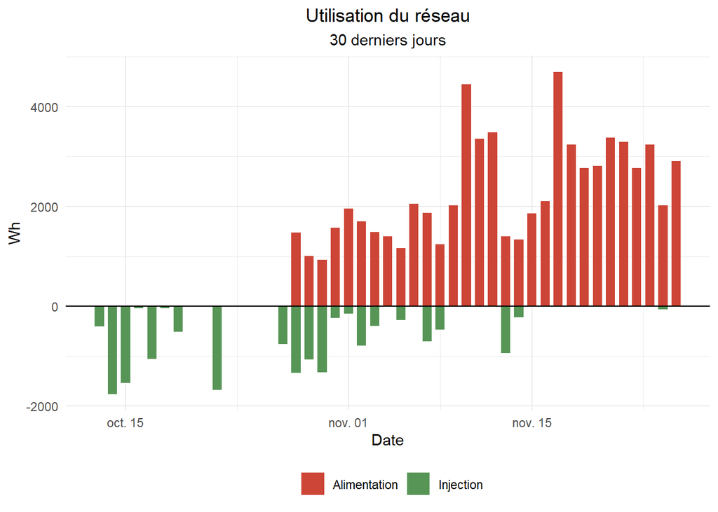

**Résumé des 10 derniers jours (en Wh)**

Résumé des 10 derniers jours

en Wh

| Date | Consommation | Production | Alimentation réseau | Injection réseau |
| --- | --- | --- | --- | --- |
| 26.11.2026 | 3 286 | 465 | 2 909 | 0 |
| 25.11.2026 | 3 862 | 1 101 | 2 020 | −57 |
| 24.11.2026 | 4 716 | 1 667 | 3 241 | 0 |
| 23.11.2026 | 3 147 | 561 | 2 774 | −1 |
| 22.11.2026 | 3 491 | 289 | 3 293 | 0 |
| 21.11.2026 | 5 506 | 2 503 | 3 379 | 0 |
| 20.11.2026 | 3 303 | 610 | 2 815 | 0 |
| 19.11.2026 | 3 079 | 478 | 2 764 | −1 |
| 18.11.2026 | 3 600 | 465 | 3 242 | 0 |
| 17.11.2026 | 4 773 | 184 | 4 696 | 0 |